# DETECTR 047 NANCY DREW

## AMP NEBuffer 4 + 2.1 Fresh Standard Curves for concentrations from 0.01uM to 10uM, including 0uM

- 0hr and 1hr single time points are first two plots
- Summation of all data points below 1hr, 3hr, 6hr and 12hr are next four plots
- No ATP standard curve
- 1.5ms integration time

### Conclusion

This looks like previous AMP standard curve with no ATP (0.5ms integration, DETECTR 042). Summing helps a little.

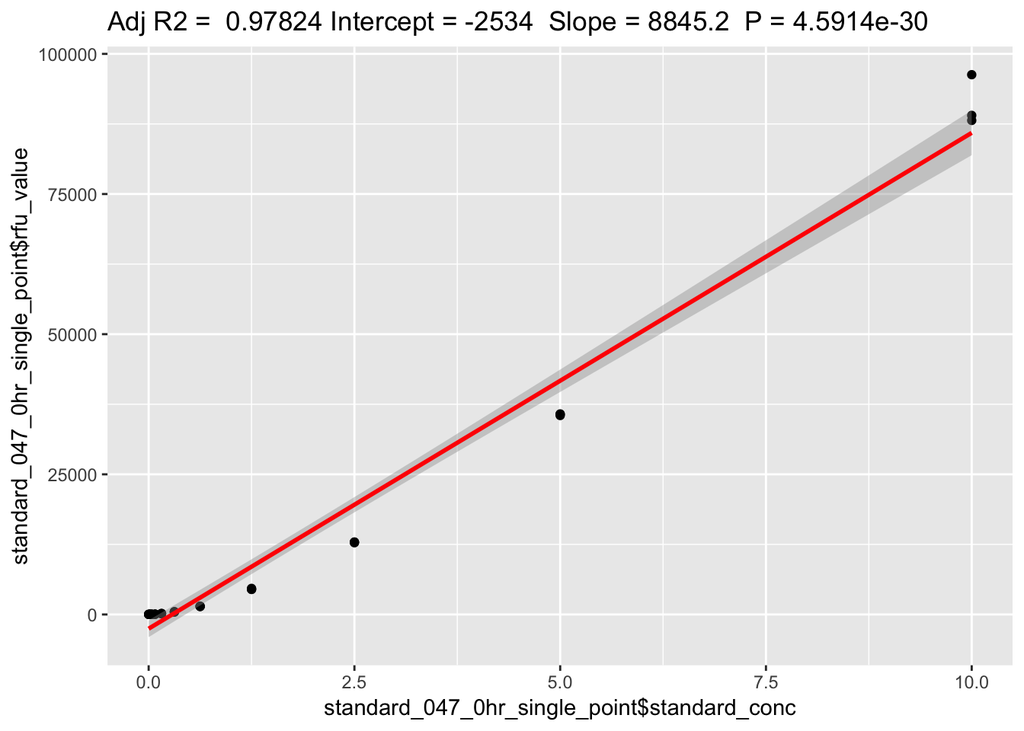

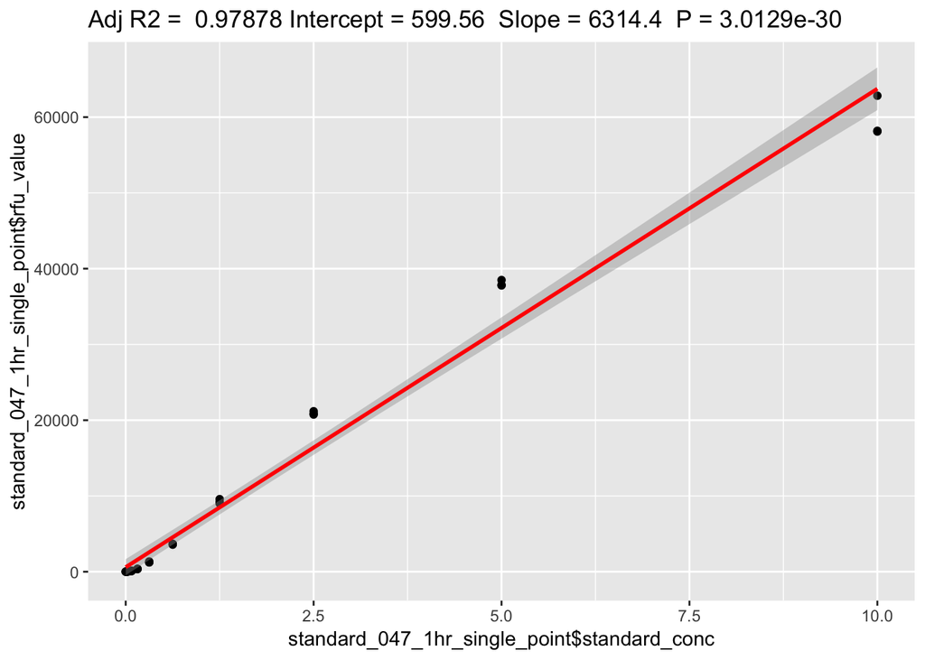

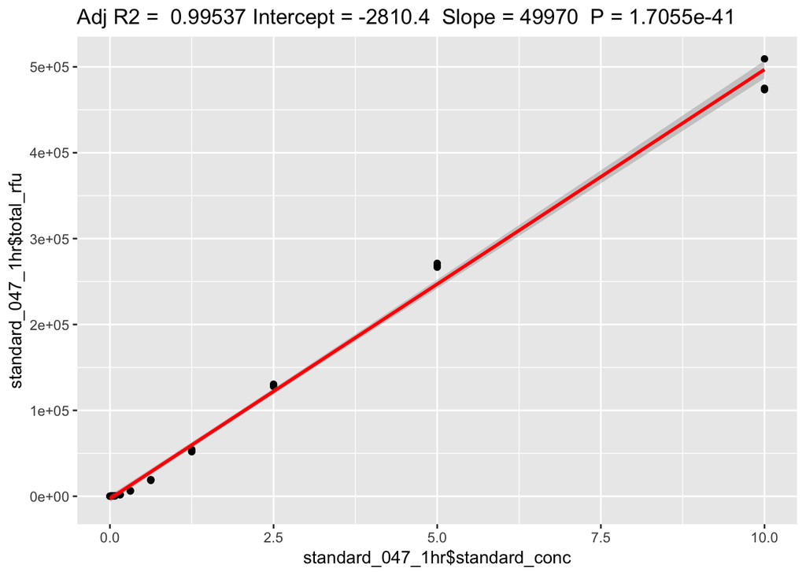

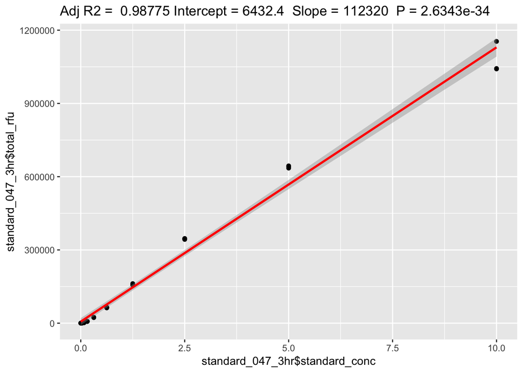

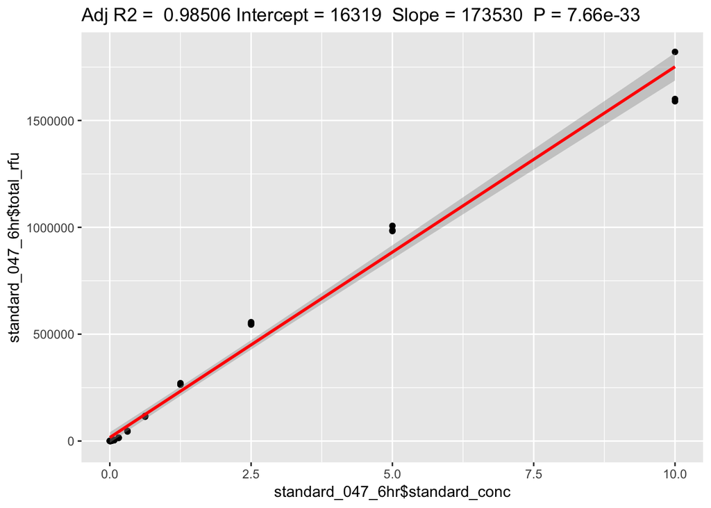

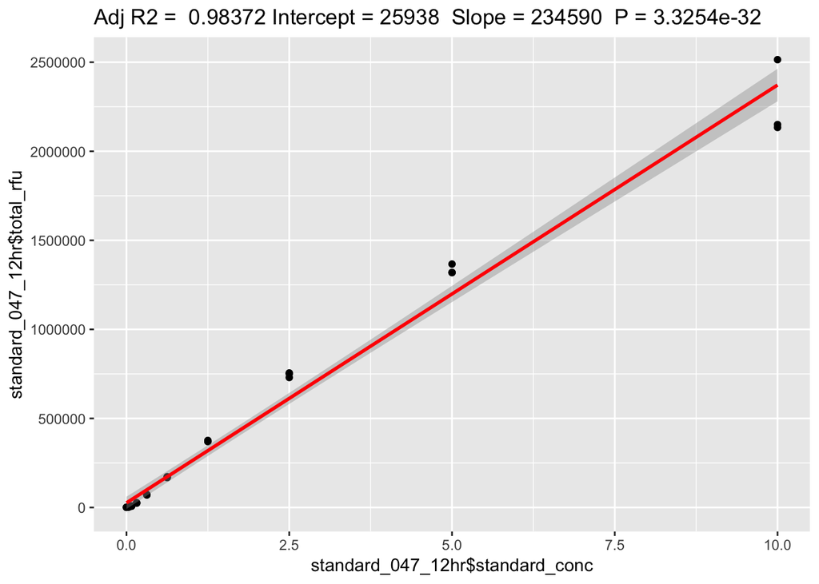

## AMP NEBuffer 4+ 2.1 Fresh Standard Curves for concentrations from 0.01uM to 0.625uM, including 0uM

- 0hr and 1hr single time points are first two plots
- Summation of all data points below 1hr, 3hr, 6hr and 12hr are next four plots
- No ATP
- 1.5ms integration time

### Conclusion

As in DETECTR 042, it is not linear in the lower regime. There is actually not a lot of noise (similar to 042)

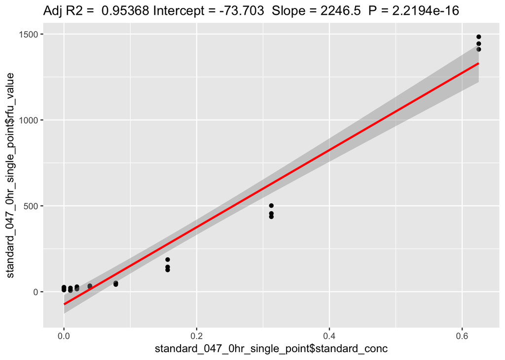

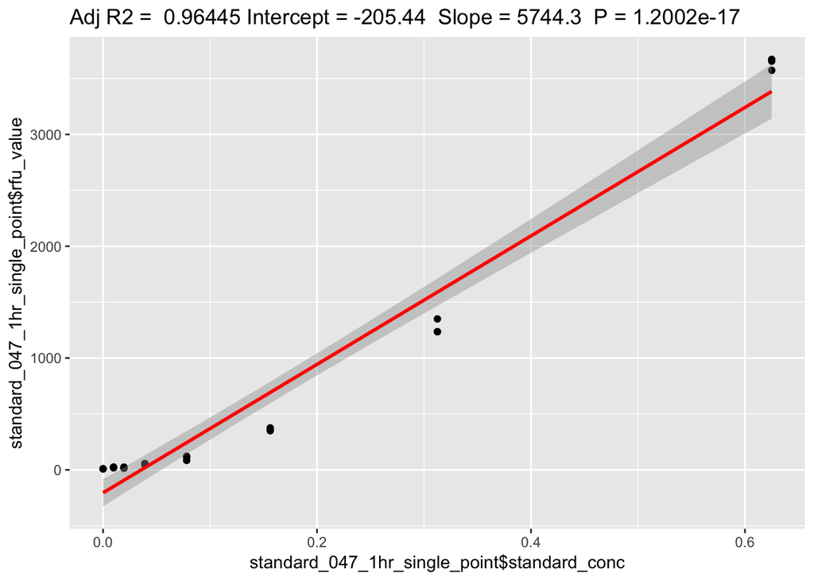

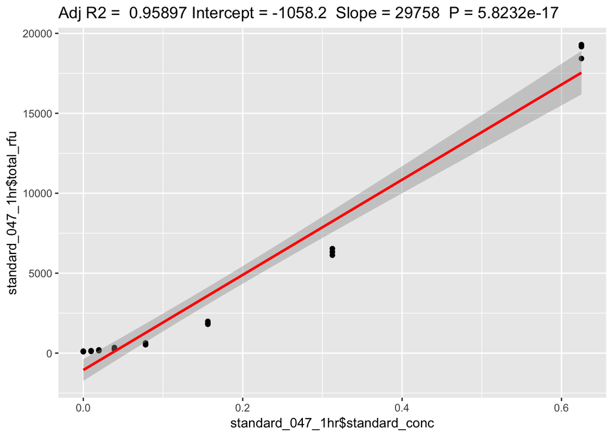

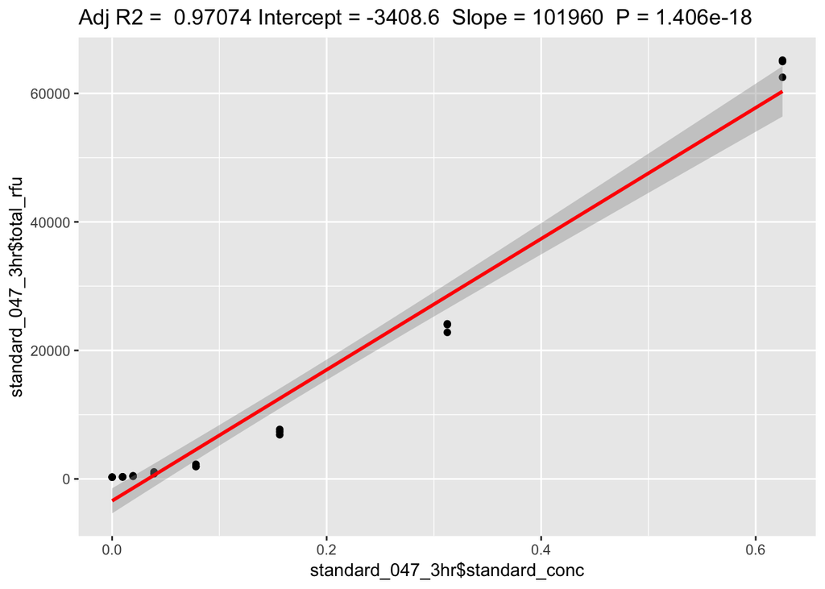

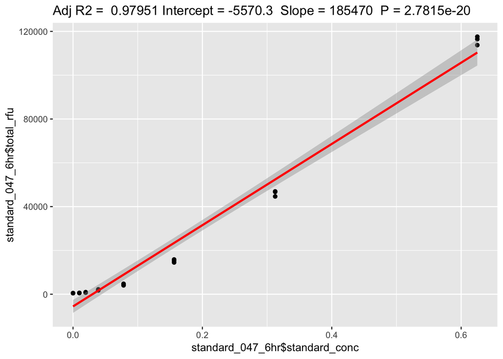

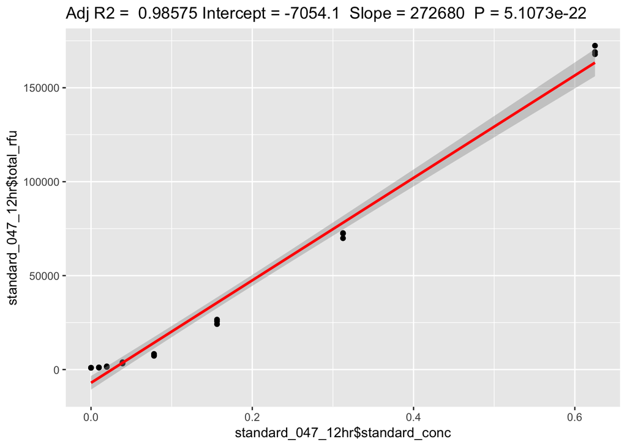

## AMP NEBuffer 4 + 2.1 Fresh Standard Curves for concentrations from 0.01uM to 0.04uM, including 0uM

### Conclusion

I would trust down to 0.018uM on the summed plots. This is better than with the 0.5ms, which was 0.04uM limit. Summing definitely helps and this is much less noisy to start with than the 0.5ms integration time.

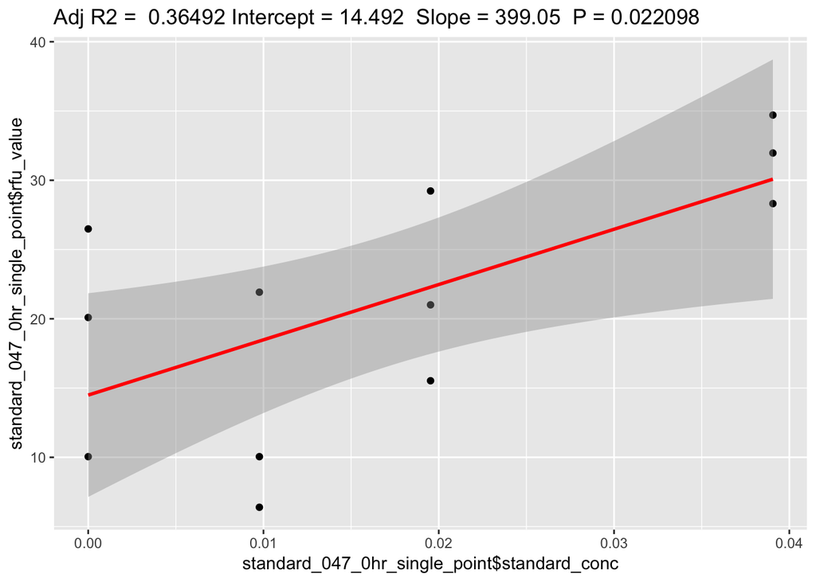

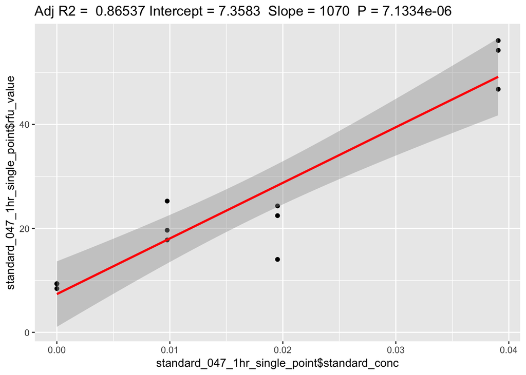

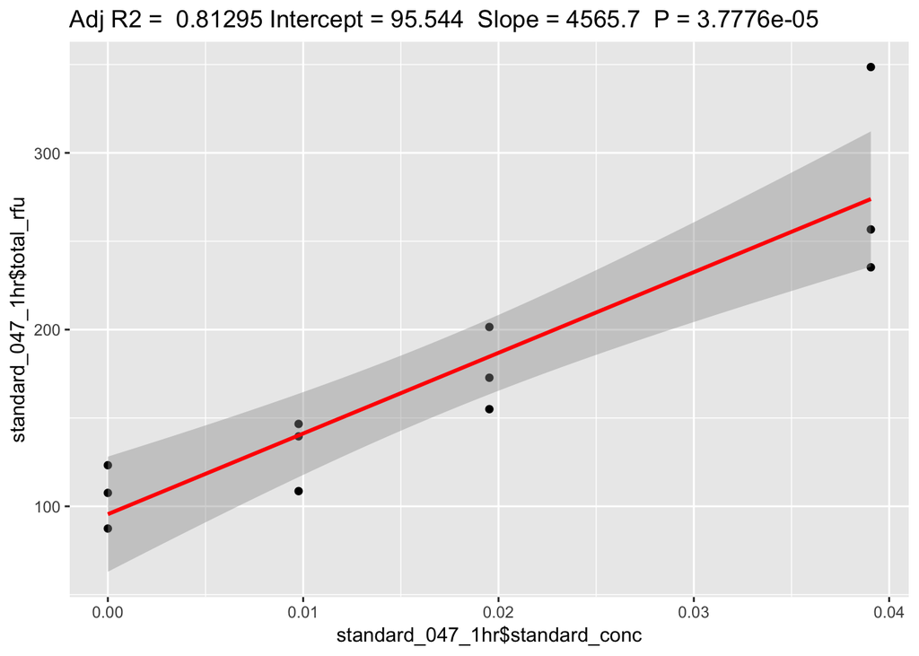

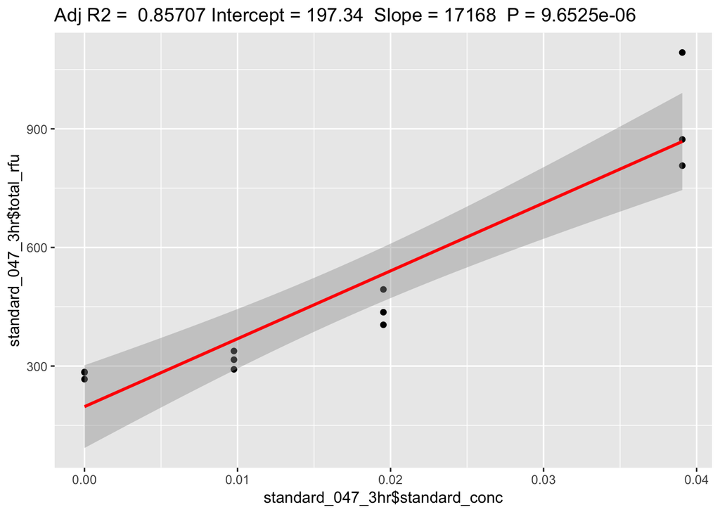

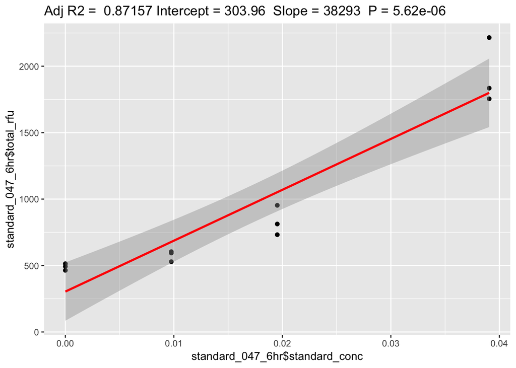

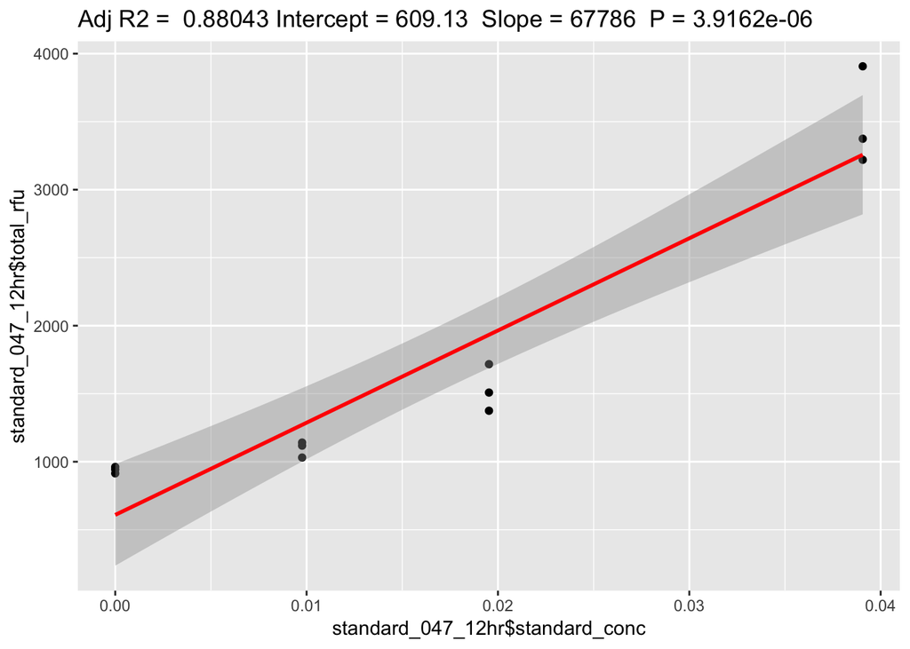

## AMP GLO NANCY DREW Controls

- Used IDT cas12a and alt-R 11C gRNA with synthetic 11C target for all
- r17A-AAAAA-r3C-phos reporter had no gRNA, no RNAseT, and no target controls
- r17Ar3C, r17A-TTATT-r3C and r17A-AAAAA-phos had no target control
- No reporter control serves as negative control for all reporter
- RFU values were converted to AMP uM concentrations using the 1hr summation regression
- In zoomed plot, r17A-TTATT-r3C reporter is removed as it is too high

### Conclusions

[figure not shown]

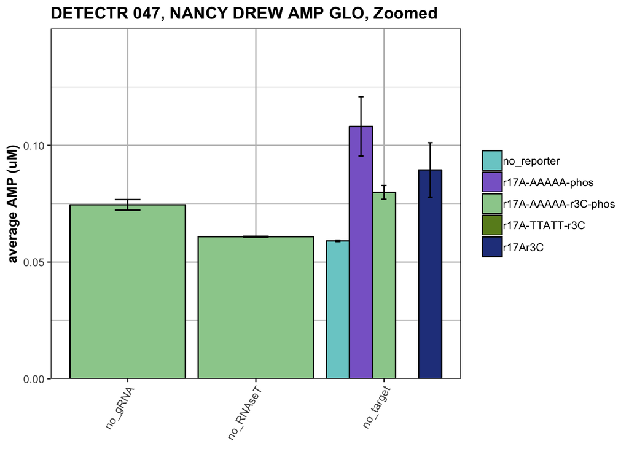

## Kinetics over time, AMP standards

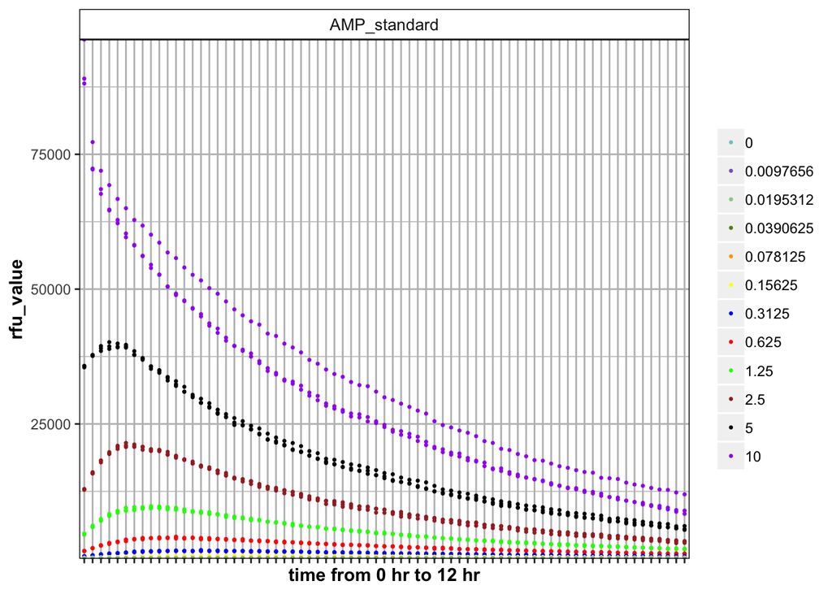